# Estudios de Informática, Multimedia y Telecomunicaciones

## 5.3 Respuesta ejercicio 4

## 5.4 Carga, resumen y explicación de los datos

### 5.4.1 Carga de los datos

En este primer punto lo que debemos de hacer es la carga de los datos, un resumen de lo que hemos leído, una explicación de los mismos, preparar los datos para el modelo y realizar un análisis de los mismos.

```r
df_lastfm = read.csv("./data/lastfm.csv", stringsAsFactors = TRUE)
head(df_lastfm)
```

```
##   user                  artist sex country
## 1    1   red hot chili peppers   f Germany
## 2    1 the black dahlia murder   f Germany
## 3    1               goldfrapp   f Germany
## 4    1        dropkick murphys   f Germany
## 5    1                le tigre   f Germany
## 6    1              schandmaul   f Germany
```

### 5.4.2 Resumen de los datos

Resumen de la estructura del dataset:

```r
str(df_lastfm)
```

```
## 'data.frame':    289955 obs. of  4 variables:
##  $ user   : int  1 1 1 1 1 1 1 1 1 1 ...
##  $ artist : Factor w/ 1004 levels "...and you will know us by the trail of dead",..: 717 851 374 282 513 751 290 430 300 896 ...
##  $ sex    : Factor w/ 2 levels "f","m": 1 1 1 1 1 1 1 1 1 1 ...
##  $ country: Factor w/ 159 levels "Afghanistan",..: 58 58 58 58 58 58 58 58 58 58 ...
```

### 5.4.3 Explicación de los datos

Revisamos la descripción de las variables y si los tipos de variable se corresponden al que hemos cargado:

**user** integer - id del usuario.

**artist** factor - artista escucahdo por el usuario.

**sex** factor - género del usuario (male o female).

**country** factor - país del usuario.

Vemos que tenemos 289955 registros y 4 variables que los caracterizan.

Este dataset está formado por 1 variable numérica (user) y 3 variable categóricas.

### 5.4.4 Preparación de los datos

Comprobamos que no haya datos sin valores:

```r
df_lastfm_copy = df_lastfm
colSums(is.na(df_lastfm_copy))
```

```
##    user  artist     sex country
##       0       0       0       0
```

De la anterior ejecución vemos que todos los campos tienen valores.

Realizamos un summary del dataset resultante para hacernos una idea del conjunto de datos que vamos a manejar, es decir, cuáles son los valores más frecuentes, las clases que tenemos…

```r
summary(df_lastfm_copy)
```

```
##       user                         artist       sex
##  Min.   :    1   radiohead            :  2704   f: 78132
##  1st Qu.: 4935   the beatles          :  2668   m:211823
##  Median : 9838   coldplay             :  2378
##  Mean   : 9852   red hot chili peppers:  1786
##  3rd Qu.:14769   muse                 :  1711
##  Max.   :19718   metallica            :  1670
##                  (Other)              :277038
##            country
##  United States : 59558
##  United Kingdom: 27638
##  Germany       : 24251
##  Poland        : 17111
##  Sweden        : 12379
##  Brazil        : 11922
##  (Other)       :137096
```

Como podemos observar, las variables tienen valores comunes, es característico ver que hay más usuarios hombres que mujeres, además, los artistas escuchados están más nivelados, sin embargo, vemos que una gran parte del dataset está basado en las escuchas de usuarios de los Estados Unidos de América, este pasís junto con Reino Unido y Alemania representan ellos solos a más de un tercio de los países registrados en el dataset.

En la siguiente gráfica podemos observar la diferencia entre el histórico de usuarios hombres y mujeres:

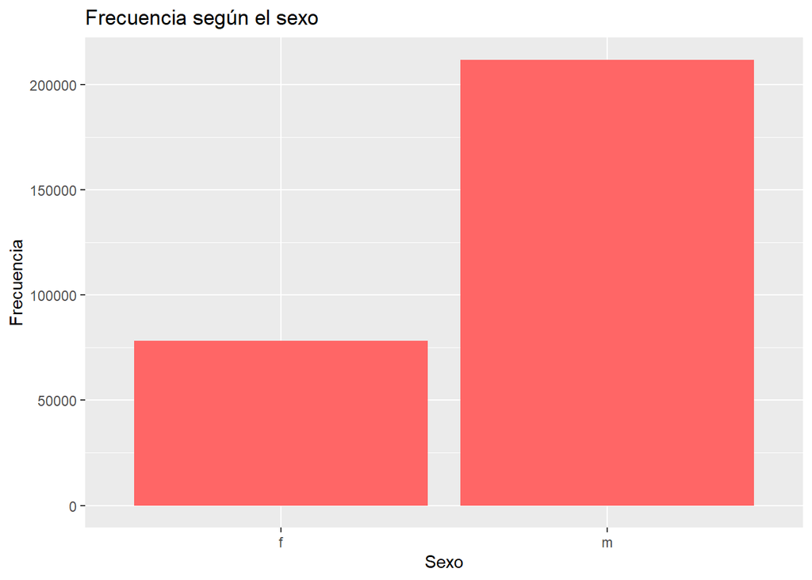

```r
ggplot(data=df_lastfm_copy,aes(x=sex)) +
  geom_bar(fill = "#FF6666") +
  ylab("Frecuencia") +
  xlab("Sexo") +
  ggtitle("Frecuencia según el sexo")
```

Podríamos hacer una representación gráfica de los artistas y de los países para ver el cómo se distrubuyen los datos, pero hay muchísimos niveles y si tratamos de acotar los niveles a un top 5 estaríamos viendo la misma información que nos proporciona la función summary, ejecutada anteriormente.

Por lo tanto, hemos comprobado que no hay registros sin datos y que los datos que contienen son coherentes, por lo que podemos proceder a aplicar el algoritmo de generación de reglas de asociación.

## 5.5 Preparación de los datos y aplicación del algoritmo apriori

Aunque nuestro dataset tiene 4 campos (el identificador del usuario, el artista escuchado, el género del usuario y el país del usuario) realmente vamos a comprobar el cómo se relacionan los usuarios con los artistas escuchados, es decir, hacernos una idea según lo que están escuchando lo que podrían escuchar.

Para trabajar de forma óptima con el algoritmo apriori debemos trabajar con trasacciones, es por ello que volvemos a hacer la lecutra de los datos y nos quedamos con el usuario y el artista, tarda mucho menos si volvemos a hacer la lectura del fichero que convertir el dataframe a un objeto de trasacciones.

Un aspecto a destacar de la creación de las transacciones es que debemos definir el formato, puede ser single (si cada línea representa un ítem) o basket (si cada línea representa una transacción completa), en nuestro caso el formato debe ser single ya que la transcción completa es el histórico de cada usuario y los items los artistas escuchados:

```r
library(arules)

transactions_lastfm = read.transactions(file = "./data/lastfm.csv", sep = ",", format = "single", header = TRUE, cols = c("user", "artist"), rm.duplicates = TRUE, encoding = "UTF-8")

transactions_lastfm
```

```
## transactions in sparse format with
##  15000 transactions (rows) and
##  1004 items (columns)
```

Como podemos apreciar, tenemos 15000 transacciones y 1004 items.

Las columnas de las transacciones se corresponden con los artistas de nuestro dataset:

```r
colnames(transactions_lastfm)[1:20]
```

```
##  [1] "...and you will know us by the trail of dead"
##  [2] "[unknown]"
##  [3] "2pac"
##  [4] "3 doors down"
##  [5] "30 seconds to mars"
##  [6] "311"
##  [7] "36 crazyfists"
##  [8] "44"
##  [9] "50 cent"
## [10] "65daysofstatic"
## [11] "a-ha"
## [12] "a day to remember"
## [13] "a fine frenzy"
## [14] "a perfect circle"
## [15] "a tribe called quest"
## [16] "abba"
## [17] "above & beyond"
## [18] "ac/dc"
## [19] "adam green"
## [20] "adele"
```

Las filas se corresponden con las transacciones que tenemos en el dataset:

```r
rownames(transactions_lastfm)[1:20]
```

```
##  [1] "1"     "1000"  "10000" "10002" "10003" "10004" "10006" "10007" "10008"
## [10] "10009" "10010" "10011" "10012" "10015" "10016" "10017" "10018" "10019"
## [19] "1002"  "10020"
```

Podemos análizar los items que tenemos en transacciones, como vemos a continuación, tenemos los artistas correspondientes a la primera trasacción, es decir, al primer usuario (si abrimos el fichero comprobamos que tiene el mismo número de artistas y que se corresponde con estos):

```r
inspect(head(transactions_lastfm, 1))
```

```
##     items                     transactionID
## [1] {dropkick murphys,
##      edguy,
##      eluveitie,
##      goldfrapp,
##      guano apes,
##      jack johnson,
##      john mayer,
##      judas priest,
##      le tigre,
##      red hot chili peppers,
##      rob zombie,
##      schandmaul,
##      the black dahlia murder,
##      the killers,
##      the rolling stones,
##      the who}                             1
```

Podemos ver cómo varía el tamaño de las transacciones:

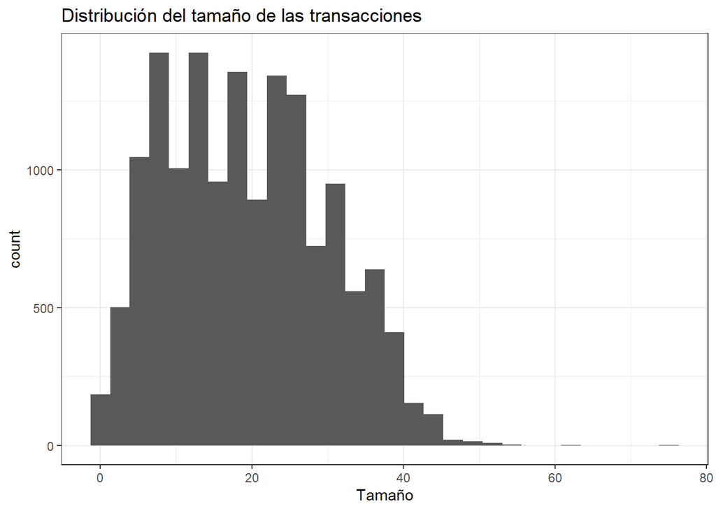

```r
  ggplot(data.frame(size(transactions_lastfm)), aes(x = size(transactions_lastfm))) +
  geom_histogram() +
  labs(title = "Distribución del tamaño de las transacciones",
       x = "Tamaño") +
  theme_bw()
```

De la anterior gráfica podemos concluir que la gran mayoría de gente escucha entre 8 y 30 artistas, pero también podemos comprobar cuáles son los artistas más escuchados/más frecuentes, es decir, los que tienen un mayor soporte:

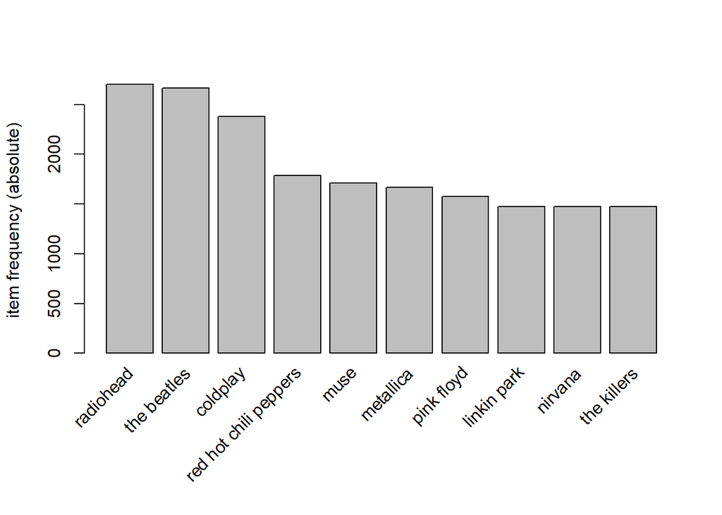

```r
itemFrequencyPlot(transactions_lastfm, topN = 10, type = "absolute")
```

```r
frecuencia_items = itemFrequency(x = transactions_lastfm, type = "absolute")
head(sort(frecuencia_items, decreasing = TRUE), 10)
```

```
##             radiohead           the beatles              coldplay
##                  2704                  2668                  2378
## red hot chili peppers                  muse             metallica
##                  1786                  1711                  1670
##            pink floyd           linkin park               nirvana
##                  1574                  1473                  1473
##           the killers
##                  1473
```

Como podemos apreciar, el top 10 de artistas más escuchados son de habla inglesa, lo cual es lógico ya que un tercio de los datos que tenemos son de Estados Unidos y Reino Unido.

```r
lastfm_rules = apriori(transactions_lastfm, parameter = list(support = 0.01, confidence = 0.5))
```

```
## Apriori
##
## Parameter specification:
##  confidence minval smax arem  aval originalSupport maxtime support minlen
##         0.5    0.1    1 none FALSE            TRUE       5    0.01      1
##  maxlen target  ext
##      10  rules TRUE
##
## Algorithmic control:
##  filter tree heap memopt load sort verbose
##     0.1 TRUE TRUE  FALSE TRUE    2    TRUE
##
## Absolute minimum support count: 150
##
## set item appearances ...[0 item(s)] done [0.00s].
## set transactions ...[1004 item(s), 15000 transaction(s)] done [0.06s].
## sorting and recoding items ... [655 item(s)] done [0.00s].
## creating transaction tree ... done [0.00s].
## checking subsets of size 1 2 3 4 done [0.02s].
## writing ... [50 rule(s)] done [0.00s].
## creating S4 object  ... done [0.00s].
```

Una vez generado el modelo, observamos el número de reglas encontradas:

```r
cat("El número de reglas encontradas son: ", length(lastfm_rules))
```

```
## El número de reglas encontradas son:  50
```

Finalmente, realizamos un análisis tanto del soporte, como de la confianza y del lift.

El soporte indica cuantas veces se han encontrado las reglas {lsh => rhs} en el dataset, cuanto más alto mejor ya que indicaría que hay una alta relación entre los artistas de si escucha uno escuchar el otro:

```r
inspect(head(sort(lastfm_rules, by = "support"), 10))[, c(1:4)]
```

```
##      lhs                        rhs           support    confidence coverage
## [1]  {beck}                  => {radiohead}   0.02926667 0.5092807  0.05746667
## [2]  {snow patrol}           => {coldplay}    0.02646667 0.5251323  0.05040000
## [3]  {keane}                 => {coldplay}    0.02226667 0.6374046  0.03493333
## [4]  {blur}                  => {radiohead}   0.01753333 0.5228628  0.03353333
## [5]  {megadeth}              => {metallica}   0.01626667 0.5281385  0.03080000
## [6]  {simon & garfunkel}     => {the beatles} 0.01540000 0.5238095  0.02940000
## [7]  {muse,the killers}      => {coldplay}    0.01513333 0.5089686  0.02973333
## [8]  {broken social scene}   => {radiohead}   0.01506667 0.5472155  0.02753333
## [9]  {radiohead,the killers} => {coldplay}    0.01506667 0.5243619  0.02873333
## [10] {david bowie,radiohead} => {the beatles} 0.01393333 0.5225000  0.02666667
##      lift     count
## [1]  2.825152 439
## [2]  3.312441 397
## [3]  4.020634 334
## [4]  2.900496 263
## [5]  4.743759 244
## [6]  2.944956 231
## [7]  3.210483 227
## [8]  3.035589 226
## [9]  3.307582 226
## [10] 2.937594 209
```

```
##                          lhs              rhs    support
## [1]                   {beck} =>   {radiohead} 0.02926667
## [2]            {snow patrol} =>    {coldplay} 0.02646667
## [3]                  {keane} =>    {coldplay} 0.02226667
## [4]                   {blur} =>   {radiohead} 0.01753333
## [5]               {megadeth} =>   {metallica} 0.01626667
## [6]      {simon & garfunkel} => {the beatles} 0.01540000
## [7]       {muse,the killers} =>    {coldplay} 0.01513333
## [8]    {broken social scene} =>   {radiohead} 0.01506667
## [9]  {radiohead,the killers} =>    {coldplay} 0.01506667
## [10] {david bowie,radiohead} => {the beatles} 0.01393333
```

Tal y como podemos observar la gran mayoría de {rhs} se corresponden con los grupos más escuchados (Radiohead, Coldplay, the beatles), pero cabe destacar que se ha “colado” el grupo metallica como uno de los grupos que más relación tiene con su antecedente {lhs}, lo cual es normal, porque su grupo antecente megadeth su género músical es igual a metallica.

Además, podemos ver que los artistas más comunes tienen antecedentes similares al género músical que hacen, por ejemplo, hay gente que para escuchar a coldplay viene de snow patrol (hace rock alternativo) y hay gente que viene de keane o de muse, los cuales también hacen rock.

Por lo tanto, podemos ver que los usuarios que escuchan un tipo de género, también escuchan otros grupos del mismo tipo de género muscial. Hay casos “especiales”, como por ejemplo hay gente que escucha a david bowie o radiohead (rock) y están relacionados con the beatles, los cuales hacen un rock más popular, más comumente conocido como pop.

La confianza habla de la probabilidad de que {rhs} se de en función de {lhs}, a mayor confianza mayor va a ser la relación entre {rhs} y {lhs}:

```r
inspect(head(sort(lastfm_rules, by = "confidence"), 10))[, c(1:3,5)]
```

```
##      lhs                                    rhs           support    confidence
## [1]  {oasis,the killers}                 => {coldplay}    0.01113333 0.6626984
## [2]  {sigur rós,the beatles}             => {radiohead}   0.01046667 0.6434426
## [3]  {keane}                             => {coldplay}    0.02226667 0.6374046
## [4]  {radiohead,snow patrol}             => {coldplay}    0.01006667 0.6344538
## [5]  {coldplay,the smashing pumpkins}    => {radiohead}   0.01093333 0.6283525
## [6]  {the beatles,the smashing pumpkins} => {radiohead}   0.01146667 0.6209386
## [7]  {bob dylan,pink floyd}              => {the beatles} 0.01033333 0.6150794
## [8]  {led zeppelin,the doors}            => {pink floyd}  0.01066667 0.5970149
## [9]  {snow patrol,the killers}           => {coldplay}    0.01040000 0.5954198
## [10] {bob dylan,the rolling stones}      => {the beatles} 0.01146667 0.5910653
##      coverage   lift     count
## [1]  0.01680000 4.180183 167
## [2]  0.01626667 3.569393 157
## [3]  0.03493333 4.020634 334
## [4]  0.01586667 4.002021 151
## [5]  0.01740000 3.485683 164
## [6]  0.01846667 3.444556 172
## [7]  0.01680000 3.458092 155
## [8]  0.01786667 5.689469 160
## [9]  0.01746667 3.755802 156
## [10] 0.01940000 3.323081 172
```

```
##                                      lhs              rhs confidence
## [1]                  {oasis,the killers} =>    {coldplay}  0.6626984
## [2]              {sigur rós,the beatles} =>   {radiohead}  0.6434426
## [3]                              {keane} =>    {coldplay}  0.6374046
## [4]              {radiohead,snow patrol} =>    {coldplay}  0.6344538
## [5]     {coldplay,the smashing pumpkins} =>   {radiohead}  0.6283525
## [6]  {the beatles,the smashing pumpkins} =>   {radiohead}  0.6209386
## [7]               {bob dylan,pink floyd} => {the beatles}  0.6150794
## [8]             {led zeppelin,the doors} =>  {pink floyd}  0.5970149
## [9]            {snow patrol,the killers} =>    {coldplay}  0.5954198
## [10]      {bob dylan,the rolling stones} => {the beatles}  0.5910653
```

Tal y como podemos apreciar hay una fuerte relación entre determinados grupos que hacen música sobre un mismo género, como oasis y the killers con coldplay.

También podemos ver que hay relaciones entre grupos que sinceramente se hacen por lo famosos que son, por ejemplo que bob dylan y the rolling stones está fuertemente relacionado con the beatles, sin embargo, hacen géneros diferentes y son tipos de personalidad completamente diferentes.

Por lo tanto, nos podemos hacer una idea de que la gran mayoría de relaciones se hacen porque los artistas hacen o el mismo género o géneros similares, pero hay casos especiales, en los que hay artistas famosos los cuales la gente los escucha por eso mismo, esto no implica que un usuario solo pueda escuchar un género o un determinado artista, pero llama la atención.

Finalmente, el lift es un parámetro que nos indica cuánto de aleatoriedad hay en las reglas. Un lift de 1 o menos es que las reglas son completamente fruto del azar:

```r
inspect(head(sort(lastfm_rules, by = "lift"), 10))[, c(1:3,7)]
```

```
##      lhs                         rhs            support    confidence
## [1]  {the pussycat dolls}     => {rihanna}      0.01040000 0.5777778
## [2]  {t.i.}                   => {kanye west}   0.01040000 0.5672727
## [3]  {judas priest}           => {iron maiden}  0.01353333 0.5075000
## [4]  {sonata arctica}         => {nightwish}    0.01346667 0.5101010
## [5]  {pink floyd,the doors}   => {led zeppelin} 0.01066667 0.5387205
## [6]  {led zeppelin,the doors} => {pink floyd}   0.01066667 0.5970149
## [7]  {megadeth}               => {metallica}    0.01626667 0.5281385
## [8]  {placebo,radiohead}      => {muse}         0.01366667 0.5137845
## [9]  {oasis,the killers}      => {coldplay}     0.01113333 0.6626984
## [10] {keane}                  => {coldplay}     0.02226667 0.6374046
##      coverage   lift      count
## [1]  0.01800000 13.415893 156
## [2]  0.01833333  8.854413 156
## [3]  0.02666667  8.562992 203
## [4]  0.02640000  8.236292 202
## [5]  0.01980000  6.802027 160
## [6]  0.01786667  5.689469 160
## [7]  0.03080000  4.743759 244
## [8]  0.02660000  4.504247 205
## [9]  0.01680000  4.180183 167
## [10] 0.03493333  4.020634 334
```

```
##                           lhs               rhs      lift
## [1]      {the pussycat dolls} =>      {rihanna} 13.415893
## [2]                    {t.i.} =>   {kanye west}  8.854413
## [3]            {judas priest} =>  {iron maiden}  8.562992
## [4]          {sonata arctica} =>    {nightwish}  8.236292
## [5]    {pink floyd,the doors} => {led zeppelin}  6.802027
## [6]  {led zeppelin,the doors} =>   {pink floyd}  5.689469
## [7]                {megadeth} =>    {metallica}  4.743759
## [8]       {placebo,radiohead} =>         {muse}  4.504247
## [9]       {oasis,the killers} =>     {coldplay}  4.180183
## [10]                  {keane} =>     {coldplay}  4.020634
```

La ejecución anterior nos da una información muy valiosa, hasta ahora las reglas se centraban más en los artistas “más famosos”, sin embargo, el lift no está indicando que hay relaciones que no son tan aleatorias como imaginábamos.

Por ejemplo, el grupo the pussycat dolls hacen música más orientado al cabaret y rihanna en ese caso su estilo musical es muy parecido, por lo que es lógico que no haya una aleatoriedad en esa regla.

Otro caso son los que escuchan a pink floyd y the doors hacen un estilo de música muy especial caracterizada en los finales de los 60 y primeros de los 70, es por ello que lógicamente van a escuchar a led zeppelin ya que los géneros son similares y son de la misma época.

Otro caso similar es el de T.I. con kenye west ambos hacen rap más comercial y son de la misma época, por lo que tiene todo el sentido del mundo que escuchen a ambos artistas, ya que si te gusta ese género y tienes dos artistas similares los vas a escuchar sí o sí.

## 5.6 Variando los parámetros de confianza y soporte

Una vez que ya hemos hecho un modelo de base que nos da una idea de cómo se relacionan los artistas, podemos tratar de mejorar ese modelo aumentando la confianza y soporte, de tal forma que vayamos obteniendo un mejor número de reglas y que estas reglas sean lo más claras posible, para tener la certeza que realmente sí que hay una relación.

En este apartado se podrían hacer muchos modelo, pero nos vamos a centrar en dos: el primero aumentado solamente el soporte y manteniendo la confianza, y un segundo modelo en el que aumentaremos solo la confianza.

Por lo tanto, en el primer modelo vamos a aumentar el soporte de 0.01 a 0.015, esto lo que significa es que aumentamos el nivel que el algormitmo considera como frecuente:

```r
lastfm_rules = apriori(transactions_lastfm, parameter = list(support = 0.015, confidence = 0.5))
```

```
## Apriori
##
## Parameter specification:
##  confidence minval smax arem  aval originalSupport maxtime support minlen
##         0.5    0.1    1 none FALSE            TRUE       5   0.015      1
##  maxlen target  ext
##      10  rules TRUE
##
## Algorithmic control:
##  filter tree heap memopt load sort verbose
##     0.1 TRUE TRUE  FALSE TRUE    2    TRUE
##
## Absolute minimum support count: 225
##
## set item appearances ...[0 item(s)] done [0.00s].
## set transactions ...[1004 item(s), 15000 transaction(s)] done [0.06s].
## sorting and recoding items ... [417 item(s)] done [0.00s].
## creating transaction tree ... done [0.00s].
## checking subsets of size 1 2 3 done [0.01s].
## writing ... [9 rule(s)] done [0.00s].
## creating S4 object  ... done [0.00s].
```

Una vez generado el modelo, observamos el número de reglas encontradas:

```r
cat("El número de reglas encontradas son: ", length(lastfm_rules))
```

```
## El número de reglas encontradas son:  9
```

Tal y como podemos recordar, en el anterior modelo teníamos 50 reglas encontradas, en este caso ya son solo 9.

Finalmente, realizamos un análisis tanto del soporte, como de la confianza y del lift.

El soporte indica cuantas veces se han encontrado las reglas {lsh => rhs} en el dataset, cuanto más alto mejor ya que indicaría que hay una alta relación entre los artistas de si escucha uno escuchar el otro:

```r
inspect(sort(lastfm_rules, by = "support"))[, c(1:4)]
```

```
##     lhs                        rhs           support    confidence coverage
## [1] {beck}                  => {radiohead}   0.02926667 0.5092807  0.05746667
## [2] {snow patrol}           => {coldplay}    0.02646667 0.5251323  0.05040000
## [3] {keane}                 => {coldplay}    0.02226667 0.6374046  0.03493333
## [4] {blur}                  => {radiohead}   0.01753333 0.5228628  0.03353333
## [5] {megadeth}              => {metallica}   0.01626667 0.5281385  0.03080000
## [6] {simon & garfunkel}     => {the beatles} 0.01540000 0.5238095  0.02940000
## [7] {muse,the killers}      => {coldplay}    0.01513333 0.5089686  0.02973333
## [8] {broken social scene}   => {radiohead}   0.01506667 0.5472155  0.02753333
## [9] {radiohead,the killers} => {coldplay}    0.01506667 0.5243619  0.02873333
##     lift     count
## [1] 2.825152 439
## [2] 3.312441 397
## [3] 4.020634 334
## [4] 2.900496 263
## [5] 4.743759 244
## [6] 2.944956 231
## [7] 3.210483 227
## [8] 3.035589 226
## [9] 3.307582 226
```

```
##                         lhs              rhs    support
## [1]                  {beck} =>   {radiohead} 0.02926667
## [2]           {snow patrol} =>    {coldplay} 0.02646667
## [3]                 {keane} =>    {coldplay} 0.02226667
## [4]                  {blur} =>   {radiohead} 0.01753333
## [5]              {megadeth} =>   {metallica} 0.01626667
## [6]     {simon & garfunkel} => {the beatles} 0.01540000
## [7]      {muse,the killers} =>    {coldplay} 0.01513333
## [8]   {broken social scene} =>   {radiohead} 0.01506667
## [9] {radiohead,the killers} =>    {coldplay} 0.01506667
```

Tal y como podemos observar la gran mayoría de {rhs} se corresponden con los grupos más escuchados (Radiohead, Coldplay, the beatles), pero cabe destacar que se ha “colado” el grupo metallica como uno de los grupos que más relación tiene con su antecedente {lhs}, lo cual es normal, porque su grupo antecente megadeth su género músical es igual a metallica.

Además, podemos ver que los artistas más comunes tienen antecedentes similares al género músical que hacen, por ejemplo, hay gente que para escuchar a coldplay viene de snow patrol (hace rock alternativo) y hay gente que viene de keane o de muse, los cuales también hacen rock.

Estas conclusiones obtenidas lógicamente son iguales que en el modelo anterior, ya que son los mismos datos lo único que ponemos más restricciones para no tener un conjunto de reglas tan alto, solo tener verdaderamente las que son llamativas.

La confianza habla de la probabilidad de que {rhs} se de en función de {lhs}, a mayor confianza mayor va a ser la relación entre {rhs} y {lhs}:

```r
inspect(sort(lastfm_rules, by = "confidence"))[, c(1:3,5)]
```

```
##     lhs                        rhs           support    confidence coverage
## [1] {keane}                 => {coldplay}    0.02226667 0.6374046  0.03493333
## [2] {broken social scene}   => {radiohead}   0.01506667 0.5472155  0.02753333
## [3] {megadeth}              => {metallica}   0.01626667 0.5281385  0.03080000
## [4] {snow patrol}           => {coldplay}    0.02646667 0.5251323  0.05040000
## [5] {radiohead,the killers} => {coldplay}    0.01506667 0.5243619  0.02873333
## [6] {simon & garfunkel}     => {the beatles} 0.01540000 0.5238095  0.02940000
## [7] {blur}                  => {radiohead}   0.01753333 0.5228628  0.03353333
## [8] {beck}                  => {radiohead}   0.02926667 0.5092807  0.05746667
## [9] {muse,the killers}      => {coldplay}    0.01513333 0.5089686  0.02973333
##     lift     count
## [1] 4.020634 334
## [2] 3.035589 226
## [3] 4.743759 244
## [4] 3.312441 397
## [5] 3.307582 226
## [6] 2.944956 231
## [7] 2.900496 263
## [8] 2.825152 439
## [9] 3.210483 227
```

```
##                         lhs              rhs confidence
## [1]                 {keane} =>    {coldplay}  0.6374046
## [2]   {broken social scene} =>   {radiohead}  0.5472155
## [3]              {megadeth} =>   {metallica}  0.5281385
## [4]           {snow patrol} =>    {coldplay}  0.5251323
## [5] {radiohead,the killers} =>    {coldplay}  0.5243619
## [6]     {simon & garfunkel} => {the beatles}  0.5238095
## [7]                  {blur} =>   {radiohead}  0.5228628
## [8]                  {beck} =>   {radiohead}  0.5092807
## [9]      {muse,the killers} =>    {coldplay}  0.5089686
```

De la ejecución anterior podemos ver realmente la relación que hay, es decir, la probablidad de que se escuche al artista {rhs} dependiendo de {lhs}, esto puede ser por diversos factores.

Por ejemplo, en el primer caso tenemos que si escuchas keane problablemnte escuches coldplay, es lógico, son mismo género musical, ambos son de Reino Unido y como hemos visto anteriormente de los Estados Unidos y Reino Unido son la gran mayoría de los usuarios.

Otro caso similar al anterior, es el de megadeth con metallica, ambos son grupos que hacen la misma música, y lo mismo sucede con simon & garfunke y the beatles, ya que hacen la música parecida (los primeros fols rock y los segundo pop rock), son de la misma época de los 60, comparten el mismo público porque ambos son de habla inglesa…

Por lo tanto, nos podemos hacer una idea de que la gran mayoría de relaciones se hacen porque los artistas hacen o el mismo género o géneros similares, son de una misma zona geográfica, son de la misma época, cantan en el mismo idioma…

Finalmente, el lift es un parámetro que nos indica cuánto de aleatoriedad hay en las reglas. Un lift de 1 o menos es que las reglas son completamente fruto del azar:

```r
inspect(sort(lastfm_rules, by = "lift"))[, c(1:3,7)]
```

```
##     lhs                        rhs           support    confidence coverage
## [1] {megadeth}              => {metallica}   0.01626667 0.5281385  0.03080000
## [2] {keane}                 => {coldplay}    0.02226667 0.6374046  0.03493333
## [3] {snow patrol}           => {coldplay}    0.02646667 0.5251323  0.05040000
## [4] {radiohead,the killers} => {coldplay}    0.01506667 0.5243619  0.02873333
## [5] {muse,the killers}      => {coldplay}    0.01513333 0.5089686  0.02973333
## [6] {broken social scene}   => {radiohead}   0.01506667 0.5472155  0.02753333
## [7] {simon & garfunkel}     => {the beatles} 0.01540000 0.5238095  0.02940000
## [8] {blur}                  => {radiohead}   0.01753333 0.5228628  0.03353333
## [9] {beck}                  => {radiohead}   0.02926667 0.5092807  0.05746667
##     lift     count
## [1] 4.743759 244
## [2] 4.020634 334
## [3] 3.312441 397
## [4] 3.307582 226
## [5] 3.210483 227
## [6] 3.035589 226
## [7] 2.944956 231
## [8] 2.900496 263
## [9] 2.825152 439
```

```
##                         lhs              rhs     lift
## [1]              {megadeth} =>   {metallica} 4.743759
## [2]                 {keane} =>    {coldplay} 4.020634
## [3]           {snow patrol} =>    {coldplay} 3.312441
## [4] {radiohead,the killers} =>    {coldplay} 3.307582
## [5]      {muse,the killers} =>    {coldplay} 3.210483
## [6]   {broken social scene} =>   {radiohead} 3.035589
## [7]     {simon & garfunkel} => {the beatles} 2.944956
## [8]                  {blur} =>   {radiohead} 2.900496
## [9]                  {beck} =>   {radiohead} 2.825152
```

Algo curioso es que al aumentar el soporte hemos obtenido un menor lift, esto significa que tenemos más aleatoriedad, lógicamente al aumentar el soporte estamos aumenta el nivel de frecuencia de los artistas, por lo que ahora solo aparecen los artistas más escuchados, Rihanna ya no sale ya que su frecuencia era menor.

Aunque haya disminuido el lift, la relaciones que se siguen produciendo son lógicas y para nada son producidas por el azar, como ya hemos comentado megadeth y metallica son grupso simalres, keane y coldplay también, por lo que no podemos hablar del azar en cuanto a estas reglas.

Finalmente, vamos a ajustar un poco más el modelo, y para ello vamos a manter el nivel de soporte pero aumetaremos el nivel de confianza de 0.5 a 0.525:

```r
lastfm_rules = apriori(transactions_lastfm, parameter = list(support = 0.015, confidence = 0.525))
```

```
## Apriori
##
## Parameter specification:
##  confidence minval smax arem  aval originalSupport maxtime support minlen
##       0.525    0.1    1 none FALSE            TRUE       5   0.015      1
##  maxlen target  ext
##      10  rules TRUE
##
## Algorithmic control:
##  filter tree heap memopt load sort verbose
##     0.1 TRUE TRUE  FALSE TRUE    2    TRUE
##
## Absolute minimum support count: 225
##
## set item appearances ...[0 item(s)] done [0.00s].
## set transactions ...[1004 item(s), 15000 transaction(s)] done [0.06s].
## sorting and recoding items ... [417 item(s)] done [0.00s].
## creating transaction tree ... done [0.00s].
## checking subsets of size 1 2 3 done [0.01s].
## writing ... [4 rule(s)] done [0.00s].
## creating S4 object  ... done [0.00s].
```

Una vez generado el modelo, observamos el número de reglas encontradas:

```r
cat("El número de reglas encontradas son: ", length(lastfm_rules))
```

```
## El número de reglas encontradas son:  4
```

Tal y como podemos recordar, en el anterior modelo teníamos 9 reglas encontradas, en este caso ya son solo 4.

Finalmente, realizamos un análisis tanto del soporte, como de la confianza y del lift.

Respecto al soporte:

```r
inspect(sort(lastfm_rules, by = "support"))[, c(1:4)]
```

```
##     lhs                      rhs         support    confidence coverage
## [1] {snow patrol}         => {coldplay}  0.02646667 0.5251323  0.05040000
## [2] {keane}               => {coldplay}  0.02226667 0.6374046  0.03493333
## [3] {megadeth}            => {metallica} 0.01626667 0.5281385  0.03080000
## [4] {broken social scene} => {radiohead} 0.01506667 0.5472155  0.02753333
##     lift     count
## [1] 3.312441 397
## [2] 4.020634 334
## [3] 4.743759 244
## [4] 3.035589 226
```

```
##                       lhs            rhs    support
## [1]         {snow patrol} =>  {coldplay} 0.02646667
## [2]               {keane} =>  {coldplay} 0.02226667
## [3]            {megadeth} => {metallica} 0.01626667
## [4] {broken social scene} => {radiohead} 0.01506667
```

En la ejecución anterior se mide la frecuencia, por lo que al aumentar la confianza buscamos que la probabilidad de que una regla suceda sea alta, por lo tanto ahora obtenemos solamente los grupos con mayor frecuencia y cuya relación es elevada.

Respecto a la confianza:

```r
inspect(sort(lastfm_rules, by = "confidence"))[, c(1:3,5)]
```

```
##     lhs                      rhs         support    confidence coverage
## [1] {keane}               => {coldplay}  0.02226667 0.6374046  0.03493333
## [2] {broken social scene} => {radiohead} 0.01506667 0.5472155  0.02753333
## [3] {megadeth}            => {metallica} 0.01626667 0.5281385  0.03080000
## [4] {snow patrol}         => {coldplay}  0.02646667 0.5251323  0.05040000
##     lift     count
## [1] 4.020634 334
## [2] 3.035589 226
## [3] 4.743759 244
## [4] 3.312441 397
```

```
##                       lhs            rhs confidence
## [1]               {keane} =>  {coldplay}  0.6374046
## [2] {broken social scene} => {radiohead}  0.5472155
## [3]            {megadeth} => {metallica}  0.5281385
## [4]         {snow patrol} =>  {coldplay}  0.5251323
```

Al igual que sucedía en el anterior apartado, nos estamos fijando en los grupos más frecuentes cuya relación es muy probable y vamoe que la relación más probable es si escuchas a keane y coldplay, lo cual tal y como hemos venido comentando a lo largo de todo el ejercicio es normal, ya que son grupos similares, de la misma zona geográfica, que cantan en el mismo idioma y cuya música es parecida.

Finalmente, el lift es un parámetro que nos indica cuánto de aleatoriedad hay en las reglas:

```r
inspect(sort(lastfm_rules, by = "lift"))[, c(1:3,7)]
```

```
##     lhs                      rhs         support    confidence coverage
## [1] {megadeth}            => {metallica} 0.01626667 0.5281385  0.03080000
## [2] {keane}               => {coldplay}  0.02226667 0.6374046  0.03493333
## [3] {snow patrol}         => {coldplay}  0.02646667 0.5251323  0.05040000
## [4] {broken social scene} => {radiohead} 0.01506667 0.5472155  0.02753333
##     lift     count
## [1] 4.743759 244
## [2] 4.020634 334
## [3] 3.312441 397
## [4] 3.035589 226
```

```
##                       lhs            rhs     lift
## [1]            {megadeth} => {metallica} 4.743759
## [2]               {keane} =>  {coldplay} 4.020634
## [3]         {snow patrol} =>  {coldplay} 3.312441
## [4] {broken social scene} => {radiohead} 3.035589
```